# Practical Machine Learning Exercise

alizashoop

April 3, 2018

## Introduction

Background

Using devices such as Jawbone Up, Nike FuelBand, and Fitbit it is now possible to collect a large amount of data about personal activity relatively inexpensively. These type of devices are part of the quantified self movement - a group of enthusiasts who take measurements about themselves regularly to improve their health, to find patterns in their behavior, or because they are tech geeks. One thing that people regularly do is quantify how much of a particular activity they do, but they rarely quantify how well they do it. In this project, your goal will be to use data from accelerometers on the belt, forearm, arm, and dumbell of 6 participants. They were asked to perform barbell lifts correctly and incorrectly in 5 different ways. More information is available from the website here: http://web.archive.org/web/20161224072740/http:/groupware.les.inf.puc-rio.br/har (see the section on the Weight Lifting Exercise Dataset).

Data

The training data for this project are available here:

https://d396qusza40orc.cloudfront.net/predmachlearn/pml-training.csv

The test data are available here:

https://d396qusza40orc.cloudfront.net/predmachlearn/pml-testing.csv

The data for this project come from this source: http://web.archive.org/web/20161224072740/http:/groupware.les.inf.puc-rio.br/har. If you use the document you create for this class for any purpose please cite them as they have been very generous in allowing their data to be used for this kind of assignment.

## Initial Exploration & Processing

```r
#load libraries necessary for modeling
library(lattice);library(ggplot2);library(caret);library(randomForest);library(rpart);library(rpart.plot)
#get and read data
datrain<-"https://d396qusza40orc.cloudfront.net/predmachlearn/pml-training.csv"
datest<-"https://d396qusza40orc.cloudfront.net/predmachlearn/pml-testing.csv"
#read files, leaving out columsn with NAs, blanks and DIV/0! entries
train<-read.csv(datrain,na.strings=c("NA","#DIV/0!", ""))
test<-read.csv(datest,na.strings=c("NA","#DIV/0!", ""))
#dim(train);dim(test);summary(train);summary(test)
#remove non-essential variables, i.e. username, timestamp, window, etc.  cols 1-7
train<-train[,-c(1:7)]
test<-test[,-c(1:7)]
#remove columns with NAs
train<-train[,colSums(is.na(train)) == 0]
test <-test[,colSums(is.na(test)) == 0]
```

Split the data set using data partitions function

```r
trainPart<-createDataPartition(y=train$classe,p=.75,list=FALSE)
trainSet<-train[trainPart,]
validSet<-train[-trainPart,]
```

Show the classe levels and frequency.

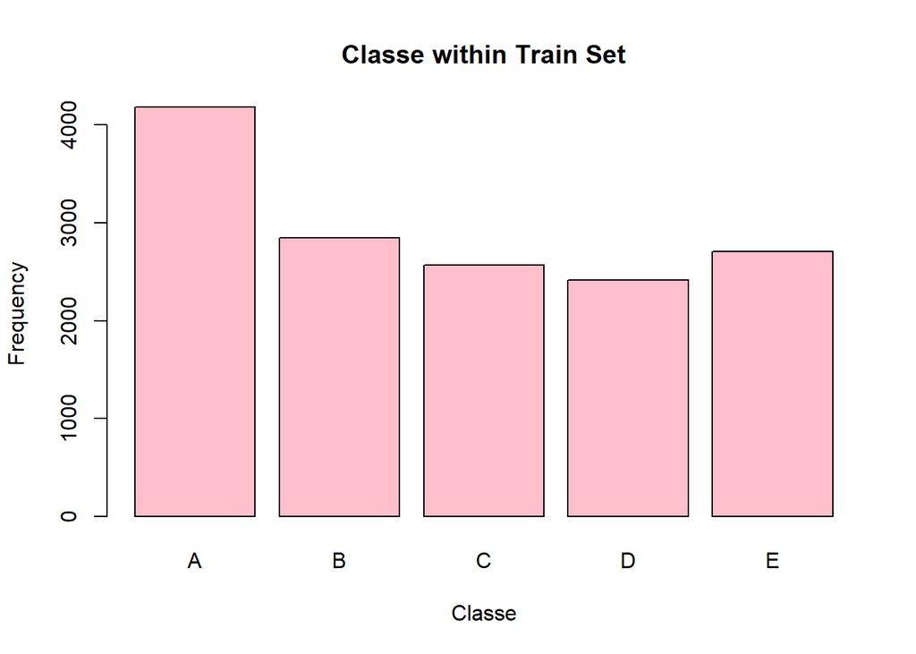

```r
#plot the classe variable
plot(trainSet$classe,col="pink",main="Classe within Train Set",xlab="Classe",ylab="Frequency")
```

## Models

We will try 3 different models using seed of 33134.

```r
set.seed(33134)
```

### Random Forest

```r
rfModel<-train(classe~.,data=trainSet,method="rf",verbose=FALSE)
rfPred<-predict(rfModel,validSet)
confusionMatrix(rfPred,validSet$classe)
```

```
## Confusion Matrix and Statistics
##
##           Reference
## Prediction    A    B    C    D    E
##          A 1394    3    0    0    0
##          B    0  945    7    0    0
##          C    0    1  847   23    0
##          D    0    0    1  780    2
##          E    1    0    0    1  899
##
## Overall Statistics
##
##                Accuracy : 0.992
##                  95% CI : (0.9891, 0.9943)
##     No Information Rate : 0.2845
##     P-Value [Acc > NIR] : < 2.2e-16
##
##                   Kappa : 0.9899
##  Mcnemar's Test P-Value : NA
##
## Statistics by Class:
##
##                      Class: A Class: B Class: C Class: D Class: E
## Sensitivity            0.9993   0.9958   0.9906   0.9701   0.9978
## Specificity            0.9991   0.9982   0.9941   0.9993   0.9995
## Pos Pred Value         0.9979   0.9926   0.9724   0.9962   0.9978
## Neg Pred Value         0.9997   0.9990   0.9980   0.9942   0.9995
## Prevalence             0.2845   0.1935   0.1743   0.1639   0.1837
## Detection Rate         0.2843   0.1927   0.1727   0.1591   0.1833
## Detection Prevalence   0.2849   0.1941   0.1776   0.1597   0.1837
## Balanced Accuracy      0.9992   0.9970   0.9924   0.9847   0.9986
```

### Classification Tree

```r
dtModel<-train(classe~.,data=trainSet,method="rpart")
dtPred<-predict(dtModel,validSet)
confusionMatrix(dtPred,validSet$classe)
```

```
## Confusion Matrix and Statistics
##
##           Reference
## Prediction    A    B    C    D    E
##          A 1272  395  398  360  113
##          B   14  326   28  148  111
##          C  104  228  429  296  257
##          D    0    0    0    0    0
##          E    5    0    0    0  420
##
## Overall Statistics
##
##                Accuracy : 0.499
##                  95% CI : (0.4849, 0.5131)
##     No Information Rate : 0.2845
##     P-Value [Acc > NIR] : < 2.2e-16
##
##                   Kappa : 0.3454
##  Mcnemar's Test P-Value : NA
##
## Statistics by Class:
##
##                      Class: A Class: B Class: C Class: D Class: E
## Sensitivity            0.9118  0.34352  0.50175   0.0000  0.46615
## Specificity            0.6392  0.92389  0.78143   1.0000  0.99875
## Pos Pred Value         0.5012  0.51994  0.32648      NaN  0.98824
## Neg Pred Value         0.9480  0.85434  0.88134   0.8361  0.89261
## Prevalence             0.2845  0.19352  0.17435   0.1639  0.18373
## Detection Rate         0.2594  0.06648  0.08748   0.0000  0.08564
## Detection Prevalence   0.5175  0.12785  0.26794   0.0000  0.08666
## Balanced Accuracy      0.7755  0.63371  0.64159   0.5000  0.73245
```

### Linear Model

```r
ldaModel<-train(classe~.,data=trainSet,method="lda")
ldaPred<-predict(ldaModel,validSet)
confusionMatrix(ldaPred,validSet$classe)
```

```
## Confusion Matrix and Statistics
##
##           Reference
## Prediction    A    B    C    D    E
##          A 1138  135   94   48   32
##          B   29  614   85   34  160
##          C   98  112  554   96   87
##          D  125   40   97  592   85
##          E    5   48   25   34  537
##
## Overall Statistics
##
##                Accuracy : 0.7004
##                  95% CI : (0.6874, 0.7132)
##     No Information Rate : 0.2845
##     P-Value [Acc > NIR] : < 2.2e-16
##
##                   Kappa : 0.621
##  Mcnemar's Test P-Value : < 2.2e-16
##
## Statistics by Class:
##
##                      Class: A Class: B Class: C Class: D Class: E
## Sensitivity            0.8158   0.6470   0.6480   0.7363   0.5960
## Specificity            0.9119   0.9221   0.9029   0.9154   0.9720
## Pos Pred Value         0.7865   0.6659   0.5850   0.6305   0.8274
## Neg Pred Value         0.9257   0.9159   0.9239   0.9465   0.9145
## Prevalence             0.2845   0.1935   0.1743   0.1639   0.1837
## Detection Rate         0.2321   0.1252   0.1130   0.1207   0.1095
## Detection Prevalence   0.2951   0.1880   0.1931   0.1915   0.1323
## Balanced Accuracy      0.8639   0.7846   0.7754   0.8258   0.7840
```

In comparing the 3 models, the best fit would be the random forest model, based on the accuracy level.

## Final Prediction

```r
finalPred <- predict(rfModel,test)
finalPred
```

```
##  [1] B A B A A E D B A A B C B A E E A B B B
## Levels: A B C D E
```